# Main Project

## SOCIAL MEDIA POSTS ON SENTIMENT ANALYSIS

## TABLE OF CONTENTS

| S. No. | Section Title |
| --- | --- |
| 1 | About the Dataset |
| 2 | Column Descriptions |
| 3 | Introduction |
| 4 | Data Preprocessing |
| 5 | Exploratory Data Analysis (EDA) |
| 6 | Text Cleaning and Preprocessing |
| 8 | Feature Extraction (TF-IDF/Bag of Words) |
| 11 | Conclusion |

## INTRODUCTION

- Social media has become one of the most influential communication platforms, where millions of users express their opinions, emotions, and feedback daily. Sentiment analysis — also known as opinion mining — is a natural language processing (NLP) technique used to identify and categorize opinions expressed in text to determine whether the sentiment is positive, negative, or neutral.
- This project focuses on analyzing the sentiments of social media posts. By applying machine learning and NLP techniques, the aim is to automatically classify user-generated content and gain insights into public opinion trends. Such analysis can help businesses, researchers, and organizations understand customer satisfaction, brand perception, and emerging issues on social media.

## ABOUT THE DATASET

- The dataset used in this project contains textual data from social media posts along with their associated sentiment labels.

Typical columns include:

```
1.Text – the actual content of a user’s post.

2.Sentiment/Label – the sentiment class (e.g., Positive, Negative, or Neutral).
```

- Before training, several data preprocessing steps were performed:

  1.Removal of unwanted characters, punctuation, URLs, and stopwords.

  2.Conversion of text to lowercase.

  3.Tokenization and lemmatization/stemming.

  4.Transformation into numerical format using TF-IDF or CountVectorizer.

## COLUMN DESCRIPTION

| Column Name | Description |
| --- | --- |
| Year | The year when the tweet was posted (e.g., 2018).. |
| Month | The month of the tweet (numeric, e.g., 8 for August). |
| Day | The day of the month the tweet was posted. |
| Time of Tweet | Indicates the time of day when the tweet was made (e.g., “morning”, “afternoon”, “evening”, “night”). |
| Text | The actual tweet or post content being analyzed. |
| Sentiment | The sentiment classification of the tweet — likely one of “positive”, “negative”, or “neutral”. |
| Platform | The social media platform where the post was made (e.g., “Twitter”). |

## LOADING LIBRARIES

```python
# 1. Import Libraries
import pandas as pd
import numpy as np
import matplotlib.pyplot as plt
import seaborn as sns
import re
import string
from wordcloud import WordCloud
from sklearn.model_selection import train_test_split
from sklearn.feature_extraction.text import TfidfVectorizer
from sklearn.naive_bayes import MultinomialNB
from sklearn.naive_bayes import BernoulliNB
from sklearn.metrics import accuracy_score, classification_report, confusion_matrix

# 2. Download necessary NLTK resources
import nltk
from nltk.corpus import stopwords
from nltk.tokenize import word_tokenize
from nltk.stem import WordNetLemmatizer
from sklearn.feature_extraction.text import TfidfVectorizer
nltk.download('punkt')
nltk.download('stopwords')
nltk.download('wordnet')
import warnings
warnings.filterwarnings('ignore')
```

## DATASET STRUCTURE AND QUALITY ASSESSMENT

```python
df=pd.read_csv(r"C:\Users\NIHAL\Downloads\sentiment_analysis.csv")
```

```python
df.head()
```

|  | Year | Month | Day | Time of Tweet | text | sentiment | Platform |
| --- | --- | --- | --- | --- | --- | --- | --- |
| 0 | 2018 | 8 | 18 | morning | What a great day!!! Looks like dream. | positive | Twitter |
| 1 | 2018 | 8 | 18 | noon | I feel sorry, I miss you here in the sea beach | positive | Facebook |
| 2 | 2017 | 8 | 18 | night | Don't angry me | negative | Facebook |
| 3 | 2022 | 6 | 8 | morning | We attend in the class just for listening teac... | negative | Facebook |
| 4 | 2022 | 6 | 8 | noon | Those who want to go, let them go | negative | Instagram |

```python
df.size
```

```
3493
```

```python
df.shape
```

```
(499, 7)
```

```python
df.info()
```

```
<class 'pandas.core.frame.DataFrame'>
RangeIndex: 499 entries, 0 to 498
Data columns (total 7 columns):
 #   Column         Non-Null Count  Dtype
---  ------         --------------  -----
 0   Year           499 non-null    int64
 1   Month          499 non-null    int64
 2   Day            499 non-null    int64
 3   Time of Tweet  499 non-null    object
 4   text           499 non-null    object
 5   sentiment      499 non-null    object
 6   Platform       499 non-null    object
dtypes: int64(3), object(4)
memory usage: 27.4+ KB
```

```python
df.describe().T
```

|  | count | mean | std | min | 25% | 50% | 75% | max |
| --- | --- | --- | --- | --- | --- | --- | --- | --- |
| Year | 499.0 | 2020.394790 | 2.830991 | 2010.0 | 2019.0 | 2021.0 | 2023.0 | 2023.0 |
| Month | 499.0 | 6.084168 | 3.652711 | 1.0 | 2.0 | 6.0 | 9.0 | 12.0 |
| Day | 499.0 | 15.693387 | 8.804673 | 1.0 | 8.0 | 15.0 | 22.0 | 31.0 |

## Sentiment Distribution :

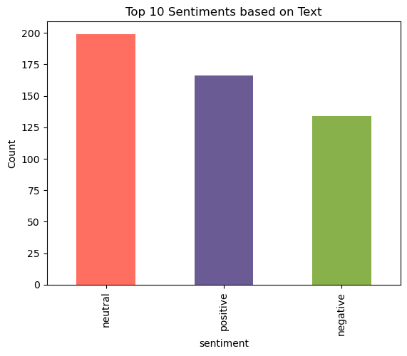

```python
colors = ['#FF6F61', '#6B5B95', '#88B04B', '#F7CAC9', '#92A8D1',
          '#955251', '#B565A7', '#009B77', '#DD4124', '#45B8AC']

df['sentiment'].value_counts().nlargest(10).plot(kind='bar', color=colors)
plt.title('Top 10 Sentiments based on Text')
plt.xlabel('sentiment')
plt.ylabel('Count')
plt.show()
```

```python
df['Platform'].value_counts()
```

```
Platform
 Instagram     171
 Facebook      165
 Twitter        91
 Twitter        68
Facebook         4
Name: count, dtype: int64
```

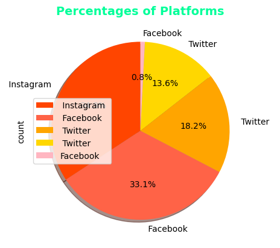

```python
colors = ['#FF4500', '#FF6347', '#FFA500', '#FFD700', '#FFB6C1']
df['Platform'].value_counts().plot(
    kind='pie',
    autopct='%1.1f%%',
    colors=colors,
    startangle=90,
    shadow=True
)
plt.title('Percentages of Platforms', color='#00FF99', fontsize=14, fontweight='bold')
plt.legend()
plt.show()
```

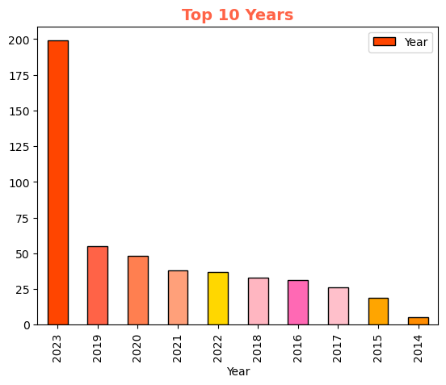

```python
colors = ['#FF4500', '#FF6347', '#FF7F50', '#FFA07A', '#FFD700',
          '#FFB6C1', '#FF69B4', '#FFC0CB', '#FFA500', '#FF8C00']

df['Year'].value_counts().nlargest(10).plot(
    kind='bar',
    color=colors,
    edgecolor='black'
)
plt.title('Top 10 Years', color='#FF6347', fontsize=14, fontweight='bold')
plt.legend(['Year'])
plt.show()
```

```python
df.columns
```

```
Index(['Year', 'Month', 'Day', 'Time of Tweet', 'text', 'sentiment',
       'Platform'],
      dtype='object')
```

```python
df = df.drop(['Year', 'Month', 'Day', 'Time of Tweet','Platform'], axis=1)
df
```

|  | text | sentiment |
| --- | --- | --- |
| 0 | What a great day!!! Looks like dream. | positive |
| 1 | I feel sorry, I miss you here in the sea beach | positive |
| 2 | Don't angry me | negative |
| 3 | We attend in the class just for listening teac... | negative |
| 4 | Those who want to go, let them go | negative |
| ... | ... | ... |
| 494 | According to , a quarter of families under six... | negative |
| 495 | the plan to not spend money is not going well | negative |
| 496 | uploading all my bamboozle pictures of facebook | neutral |
| 497 | congratulations ! you guys finish a month ear... | positive |
| 498 | actually, I wish I was back in Tahoe. I miss... | negative |

499 rows × 2 columns

## PREPROCESSING TEXT DATA

```python
nltk.download('punkt')
nltk.download('stopwords')
nltk.download('wordnet')
```

```
True
```

```python
df['text'] = df['text'].astype(str)
```

```python
def wordopt(text):
    text = text.lower()
    text = re.sub(r"http\S+|www\S+|https\S+", '', text)
    text = re.sub(r'\@w+|\#','', text)
    text = re.sub(r'[^A-Za-z\s]', '', text)
    text = re.sub(r'\s+', ' ', text).strip()
    return text
```

```python
df['text'] = df['text'].apply(wordopt)
```

```python
lemmatizer = WordNetLemmatizer()
stop_words = set(stopwords.words('english'))
```

```python
def preprocess_text(text):
    words = word_tokenize(text)
    words = [lemmatizer.lemmatize(w) for w in words if w not in stop_words]
    return ' '.join(words)
```

```python
df['text'] = df['text'].apply(preprocess_text)
```

```python
print("✅ Text preprocessing complete!")
print(df[['text', 'text']].head())
```

```
✅ Text preprocessing complete!
                                                text  \
0                          great day look like dream
1                          feel sorry miss sea beach
2                                         dont angry
3  attend class listening teacher reading slide n...
4                                     want go let go

                                                text
0                          great day look like dream
1                          feel sorry miss sea beach
2                                         dont angry
3  attend class listening teacher reading slide n...
4                                     want go let go
```

## WORD CLOUD

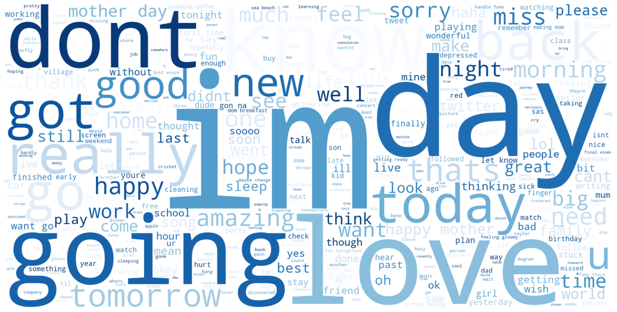

```python
# Step 1: Make sure pandas is imported and your DataFrame exists
import pandas as pd
from wordcloud import WordCloud
import matplotlib.pyplot as plt

all_reviews = " ".join(df['text'].dropna().astype(str).tolist())

# Step 2: Generate the WordCloud
wc = WordCloud(
    max_words=400,
    width=1600,
    height=800,
    background_color='white',
    colormap='Blues',     # clean blue tones
    contour_color='#004080',
    contour_width=2,
    prefer_horizontal=1.0
).generate(all_reviews)

# Step 3: Display the WordCloud
plt.figure(figsize=(20, 10))
plt.imshow(wc, interpolation='bilinear')
plt.axis('off')  # remove axes
plt.show()
```

## DATA SPLITTING

```python
x=df['text']
y=df['sentiment']
print(x)
print(y)
```

```
0                              great day look like dream
1                              feel sorry miss sea beach
2                                             dont angry
3      attend class listening teacher reading slide n...
4                                         want go let go
                             ...
494            according quarter family six live poverty
495                          plan spend money going well
496                 uploading bamboozle picture facebook
497           congratulation guy finish month early booo
498                        actually wish back tahoe miss
Name: text, Length: 499, dtype: object
0      positive
1      positive
2      negative
3      negative
4      negative
         ...
494    negative
495    negative
496     neutral
497    positive
498    negative
Name: sentiment, Length: 499, dtype: object
```

```python
x_train,x_test,y_train,y_test=train_test_split(x,y,test_size=0.25,random_state=42)
```

```python
print(x_train.shape,x_test.shape,y_train.shape,y_test.shape)
```

```
(374,) (125,) (374,) (125,)
```

## NATURAL LANGUAGE PROCESSING

```python
vectorization=TfidfVectorizer()
xv_train=vectorization.fit_transform(x_train)
xv_test=vectorization.transform(x_test)
```

```python
xv_train
```

```
<374x1059 sparse matrix of type '<class 'numpy.float64'>'
	with 2352 stored elements in Compressed Sparse Row format>
```

```python
xv_train.shape
```

```
(374, 1059)
```

```python
xv_test.shape
```

```
(125, 1059)
```

## NAIVE BAYES THEOREM

### MultinomialNB

```python
model1 = MultinomialNB()
model1.fit(xv_train,y_train)
predict1 = model1.predict(xv_test)
predict1
```

[output not shown]

```python
model2 = MultinomialNB()
model2.fit(xv_train,y_train)
predict2 = model2.predict(xv_train)
predict2
```

[output not shown]

[output cut: 16 more lines]

[output not shown]

```python
print(accuracy_score(y_test,predict1))
```

```
0.608
```

```python
print(accuracy_score(y_train,predict2))
```

```
0.946524064171123
```

### BernoulliNB

```python
model3 = BernoulliNB()
model3.fit(xv_train,y_train)
predict3 = model3.predict(xv_test)
predict3
```

[output not shown]

```python
model4 = BernoulliNB()
model4.fit(xv_train,y_train)
predict4 = model4.predict(xv_train)
predict4
```

[output not shown]

[output cut: 13 more lines]

[output not shown]

```python
print(accuracy_score(y_test,predict3))
```

```
0.44
```

```python
print(accuracy_score(y_train,predict4))
```

```
0.8074866310160428
```

## CONCLUSION

- This project successfully demonstrates how Natural Language Processing and Machine Learning can be applied to understand sentiments in social media posts. By converting unstructured textual data into meaningful insights, the system can automatically detect positive and negative emotions.
- The trained model can be used for:

  1.Monitoring brand reputation,

  2.MultinomialNB is the best model of the project

  3.Analyzing social trends in real time.
- Future improvements may include using deep learning models (e.g., LSTM, BERT) to handle context more accurately and enhance prediction performance.